# EXPLORATORY DATA ANALYSIS ON GLOBAL TERRORISM

**LEECHITA G**

```python
import pandas as pd
import matplotlib.pyplot as plt
import seaborn as sns
```

```python
df=pd.read_csv(r'C:\Users\Leechita G\Desktop\leems\INTERN June 2023\TASKS\globalterrorismdb_0718dist.csv',encoding='ISO-8859-1') #import data as dataframe
```

```
C:\Users\Leechita G\anaconda3\lib\site-packages\IPython\core\interactiveshell.py:3444: DtypeWarning: Columns (4,6,31,33,61,62,63,76,79,90,92,94,96,114,115,121) have mixed types.Specify dtype option on import or set low_memory=False.
  exec(code_obj, self.user_global_ns, self.user_ns)
```

```python
df.head()
```

|  | eventid | iyear | imonth | iday | approxdate | extended | resolution | country | country_txt | region | ... | addnotes | scite1 | scite2 | scite3 | dbsource | INT_LOG | INT_IDEO | INT_MISC | INT_ANY | related |
| --- | --- | --- | --- | --- | --- | --- | --- | --- | --- | --- | --- | --- | --- | --- | --- | --- | --- | --- | --- | --- | --- |
| 0 | 197000000001 | 1970 | 7 | 2 | NaN | 0 | NaN | 58 | Dominican Republic | 2 | ... | NaN | NaN | NaN | NaN | PGIS | 0 | 0 | 0 | 0 | NaN |
| 1 | 197000000002 | 1970 | 0 | 0 | NaN | 0 | NaN | 130 | Mexico | 1 | ... | NaN | NaN | NaN | NaN | PGIS | 0 | 1 | 1 | 1 | NaN |
| 2 | 197001000001 | 1970 | 1 | 0 | NaN | 0 | NaN | 160 | Philippines | 5 | ... | NaN | NaN | NaN | NaN | PGIS | -9 | -9 | 1 | 1 | NaN |
| 3 | 197001000002 | 1970 | 1 | 0 | NaN | 0 | NaN | 78 | Greece | 8 | ... | NaN | NaN | NaN | NaN | PGIS | -9 | -9 | 1 | 1 | NaN |
| 4 | 197001000003 | 1970 | 1 | 0 | NaN | 0 | NaN | 101 | Japan | 4 | ... | NaN | NaN | NaN | NaN | PGIS | -9 | -9 | 1 | 1 | NaN |

5 rows × 135 columns

# DATA CLEANING AND DATA PROCESSING

```python
df.columns
```

```
Index(['eventid', 'iyear', 'imonth', 'iday', 'approxdate', 'extended',
       'resolution', 'country', 'country_txt', 'region',
       ...
       'addnotes', 'scite1', 'scite2', 'scite3', 'dbsource', 'INT_LOG',
       'INT_IDEO', 'INT_MISC', 'INT_ANY', 'related'],
      dtype='object', length=135)
```

**RENAMING THE NECESSARY COLUMNS**

```python
df.rename(columns={'iyear':'Year','imonth':'Month','iday':'Day','country_txt':'Country','provstate':'state','region_txt':'Region','attacktype1_txt':'AttackType','target1':'Target','nkill':'Killed','nwound':'Wounded','summary':'Summary','gname':'Group','targtype1_txt':'Target_type','weaptype1_txt':'Weapon_type','motive':'Motive'},inplace=True)
```

```python
df.rename(columns={'state':'State','city':'City','latitude':'Latitude','longitude':'Longitude'},inplace=True)
```

**FILTERING OUT THE NECESSARY COLUMNS FROM DATASET**

```python
df=df[['Year','Month','Day','Country','State','Region','City','Latitude','Longitude','AttackType','Killed',
               'Wounded','Target','Summary','Group','Target_type','Weapon_type','Motive']]
df
```

|  | Year | Month | Day | Country | State | Region | City | Latitude | Longitude | AttackType | Killed | Wounded | Target | Summary | Group | Target_type | Weapon_type | Motive |
| --- | --- | --- | --- | --- | --- | --- | --- | --- | --- | --- | --- | --- | --- | --- | --- | --- | --- | --- |
| 0 | 1970 | 7 | 2 | Dominican Republic | NaN | Central America & Caribbean | Santo Domingo | 18.456792 | -69.951164 | Assassination | 1.0 | 0.0 | Julio Guzman | NaN | MANO-D | Private Citizens & Property | Unknown | NaN |
| 1 | 1970 | 0 | 0 | Mexico | Federal | North America | Mexico city | 19.371887 | -99.086624 | Hostage Taking (Kidnapping) | 0.0 | 0.0 | Nadine Chaval, daughter | NaN | 23rd of September Communist League | Government (Diplomatic) | Unknown | NaN |
| 2 | 1970 | 1 | 0 | Philippines | Tarlac | Southeast Asia | Unknown | 15.478598 | 120.599741 | Assassination | 1.0 | 0.0 | Employee | NaN | Unknown | Journalists & Media | Unknown | NaN |
| 3 | 1970 | 1 | 0 | Greece | Attica | Western Europe | Athens | 37.997490 | 23.762728 | Bombing/Explosion | NaN | NaN | U.S. Embassy | NaN | Unknown | Government (Diplomatic) | Explosives | NaN |
| 4 | 1970 | 1 | 0 | Japan | Fukouka | East Asia | Fukouka | 33.580412 | 130.396361 | Facility/Infrastructure Attack | NaN | NaN | U.S. Consulate | NaN | Unknown | Government (Diplomatic) | Incendiary | NaN |
| ... | ... | ... | ... | ... | ... | ... | ... | ... | ... | ... | ... | ... | ... | ... | ... | ... | ... | ... |
| 181686 | 2017 | 12 | 31 | Somalia | Middle Shebelle | Sub-Saharan Africa | Ceelka Geelow | 2.359673 | 45.385034 | Armed Assault | 1.0 | 2.0 | Checkpoint | 12/31/2017: Assailants opened fire on a Somali... | Al-Shabaab | Military | Firearms | NaN |
| 181687 | 2017 | 12 | 31 | Syria | Lattakia | Middle East & North Africa | Jableh | 35.407278 | 35.942679 | Bombing/Explosion | 2.0 | 7.0 | Hmeymim Air Base | 12/31/2017: Assailants launched mortars at the... | Muslim extremists | Military | Explosives | NaN |
| 181688 | 2017 | 12 | 31 | Philippines | Maguindanao | Southeast Asia | Kubentog | 6.900742 | 124.437908 | Facility/Infrastructure Attack | 0.0 | 0.0 | Houses | 12/31/2017: Assailants set fire to houses in K... | Bangsamoro Islamic Freedom Movement (BIFM) | Private Citizens & Property | Incendiary | NaN |
| 181689 | 2017 | 12 | 31 | India | Manipur | South Asia | Imphal | 24.798346 | 93.940430 | Bombing/Explosion | 0.0 | 0.0 | Office | 12/31/2017: Assailants threw a grenade at a Fo... | Unknown | Government (General) | Explosives | NaN |
| 181690 | 2017 | 12 | 31 | Philippines | Maguindanao | Southeast Asia | Cotabato City | 7.209594 | 124.241966 | Bombing/Explosion | 0.0 | 0.0 | Unknown | 12/31/2017: An explosive device was discovered... | Unknown | Unknown | Explosives | NaN |

181691 rows × 18 columns

**CHECK FOR NULL VALUES IN DATASET**

```python
df.isnull().sum().sum()          #total of 234487 null values in dataset
```

```
234487
```

```python
df.isnull().sum()                #null values in each column
```

```
Year                0
Month               0
Day                 0
Country             0
State             421
Region              0
City              434
Latitude         4556
Longitude        4557
AttackType          0
Killed          10313
Wounded         16311
Target            636
Summary         66129
Group               0
Target_type         0
Weapon_type         0
Motive         131130
dtype: int64
```

```python
len(df.index)                   #there is a total of 181691 records in the dataset
```

```
181691
```

```python
print("Year with the most attacks:",df['Year'].value_counts().idxmax())
print("Month with the most attacks:",df['Month'].value_counts().idxmax())
print("Country with the most attacks:",df['Country'].value_counts().idxmax())
print("City with the most attacks:",df['City'].value_counts().idxmax())
print("State with the most attacks:",df['State'].value_counts().idxmax())
print("Region with the most attacks:",df['Region'].value_counts().idxmax())
print("Group with the most attacks:",df['Group'].value_counts().idxmax())
print("Most Attack Types:",df['AttackType'].value_counts().idxmax())
```

```
Year with the most attacks: 2014
Month with the most attacks: 5
Country with the most attacks: Iraq
City with the most attacks: Unknown
State with the most attacks: Baghdad
Region with the most attacks: Middle East & North Africa
Group with the most attacks: Unknown
Most Attack Types: Bombing/Explosion
```

# DATA VISUALISATION

**YEAR AND ATTACKS**

```python
df_yr =df.groupby('Year').agg({'Year': [("Attack","count")]})
df_yr=pd.DataFrame(df_yr)
df_yr
```

| Year | Year Attack |
| --- | --- |
| 1970 | 651 |
| 1971 | 471 |
| 1972 | 568 |
| 1973 | 473 |
| 1974 | 581 |
| 1975 | 740 |
| 1976 | 923 |
| 1977 | 1319 |
| 1978 | 1526 |
| 1979 | 2662 |
| 1980 | 2662 |
| 1981 | 2586 |
| 1982 | 2544 |
| 1983 | 2870 |
| 1984 | 3495 |
| 1985 | 2915 |
| 1986 | 2860 |
| 1987 | 3183 |
| 1988 | 3721 |
| 1989 | 4324 |
| 1990 | 3887 |
| 1991 | 4683 |
| 1992 | 5071 |
| 1994 | 3456 |
| 1995 | 3081 |
| 1996 | 3058 |
| 1997 | 3197 |
| 1998 | 934 |
| 1999 | 1395 |
| 2000 | 1814 |
| 2001 | 1906 |
| 2002 | 1333 |
| 2003 | 1278 |
| 2004 | 1166 |
| 2005 | 2017 |
| 2006 | 2758 |
| 2007 | 3242 |
| 2008 | 4805 |
| 2009 | 4721 |
| 2010 | 4826 |
| 2011 | 5076 |
| 2012 | 8522 |
| 2013 | 12036 |
| 2014 | 16903 |
| 2015 | 14965 |
| 2016 | 13587 |
| 2017 | 10900 |

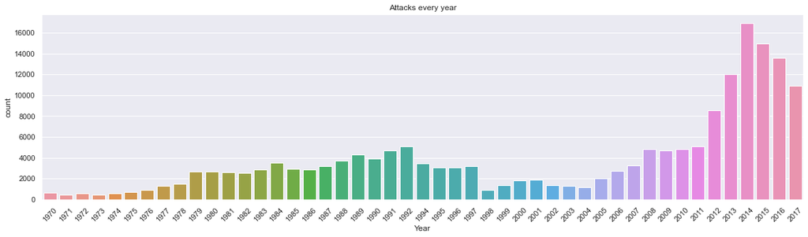

```python
yr_plt=sns.countplot(x=df["Year"],figure=plt.figure(figsize=(20,5)))
yr_plt.set_xticklabels(yr_plt.get_xticklabels(), rotation=45)
plt.title('Attacks every year')
```

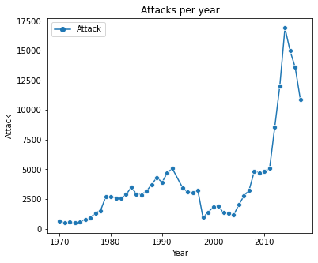

```python
import matplotlib.pyplot as plt
import seaborn as sns
lp=sns.lineplot(data=df_yr['Year'], markers=True,figure=plt.figure(figsize=(6,5))).set(title='Attacks per year')
plt.xlabel('Year')
plt.ylabel('Attack')
plt.show()
```

ANALYSIS:  
Attacks increased from 1970 till 1992 and then gradually decreased. It rose sharply from 2008 until 2014 and then decreased.

**MONTH AND ATTACKS**

```python
df_month =df.groupby('Month').agg({'Month': [("Attack","count")]})
df_month=pd.DataFrame(df_month)
df_month
```

| Month | Month Attack |
| --- | --- |
| 0 | 20 |
| 1 | 14936 |
| 2 | 13879 |
| 3 | 15257 |
| 4 | 15152 |
| 5 | 16875 |
| 6 | 15359 |
| 7 | 16268 |
| 8 | 15800 |
| 9 | 14180 |
| 10 | 15563 |
| 11 | 14906 |
| 12 | 13496 |

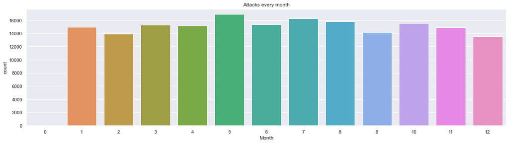

```python
sns.countplot(x=df["Month"],figure=plt.figure(figsize=(20,5)))
plt.title('Attacks every month')
```

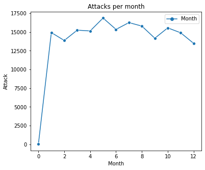

```python
# import matplotlib.pyplot as plt
import seaborn as sns
lp=sns.lineplot(data=df_month, markers=True,figure=plt.figure(figsize=(6,5))).set(title='Attacks per month')
plt.xlabel('Month')
plt.ylabel('Attack')
plt.show()
```

ANALYSIS:  
Almost all months from January to December have equal contribution.

**DAYS AND ATTACKS**

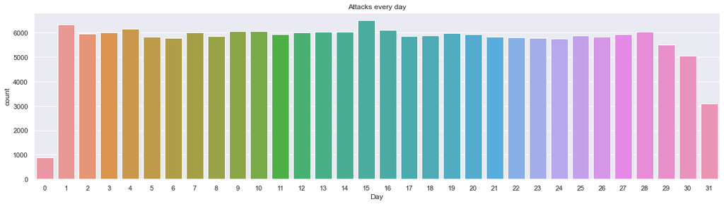

```python
sns.countplot(x=df["Day"],figure=plt.figure(figsize=(20,5)))
plt.title('Attacks every day')
```

ANALYSIS:  
Almost all days have higher attacks.

**COUNTRY AND ATTACKS**

```python
df_country =df.groupby('Country').agg({'Country': [("Attack","count")]})
df_country=pd.DataFrame(df_country)
df_country
```

| Country | Country Attack |
| --- | --- |
| Afghanistan | 12731 |
| Albania | 80 |
| Algeria | 2743 |
| Andorra | 1 |
| Angola | 499 |
| ... | ... |
| Yemen | 3347 |
| Yugoslavia | 203 |
| Zaire | 50 |
| Zambia | 62 |
| Zimbabwe | 101 |

205 rows × 1 columns

```
C:\Users\Leechita G\anaconda3\lib\site-packages\seaborn\_decorators.py:36: FutureWarning: Pass the following variables as keyword args: x, y. From version 0.12, the only valid positional argument will be `data`, and passing other arguments without an explicit keyword will result in an error or misin…
  warnings.warn(
```

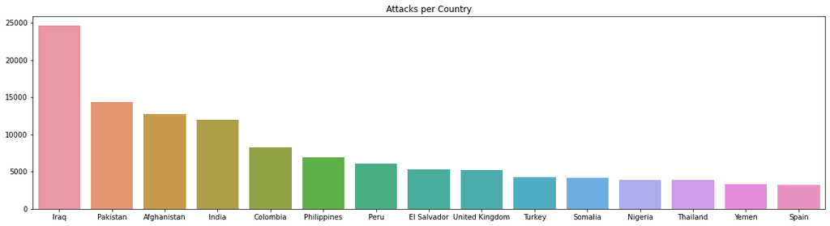

```python
sns.barplot(df['Country'].value_counts()[:15].index,df['Country'].value_counts()[:15].values,figure=plt.figure(figsize=(20,5)))
plt.title('Attacks per Country')
```

ANALYSIS:  
Out of 205 countries, these are the top few countries that are prone to higher attacks and would require additional security.

1. Iraq
2. Pakistan
3. Afghanistan
4. India

**REGION AND ATTACK**

```python
df_region =df.groupby('Region').agg({'Region': [("Attack","count")]})
df_region=pd.DataFrame(df_region)
df_region
```

| Region | Region Attack |
| --- | --- |
| Australasia & Oceania | 282 |
| Central America & Caribbean | 10344 |
| Central Asia | 563 |
| East Asia | 802 |
| Eastern Europe | 5144 |
| Middle East & North Africa | 50474 |
| North America | 3456 |
| South America | 18978 |
| South Asia | 44974 |
| Southeast Asia | 12485 |
| Sub-Saharan Africa | 17550 |
| Western Europe | 16639 |

```
C:\Users\Leechita G\anaconda3\lib\site-packages\seaborn\_decorators.py:36: FutureWarning: Pass the following variables as keyword args: x, y. From version 0.12, the only valid positional argument will be `data`, and passing other arguments without an explicit keyword will result in an error or misin…
  warnings.warn(
```

[output not shown]

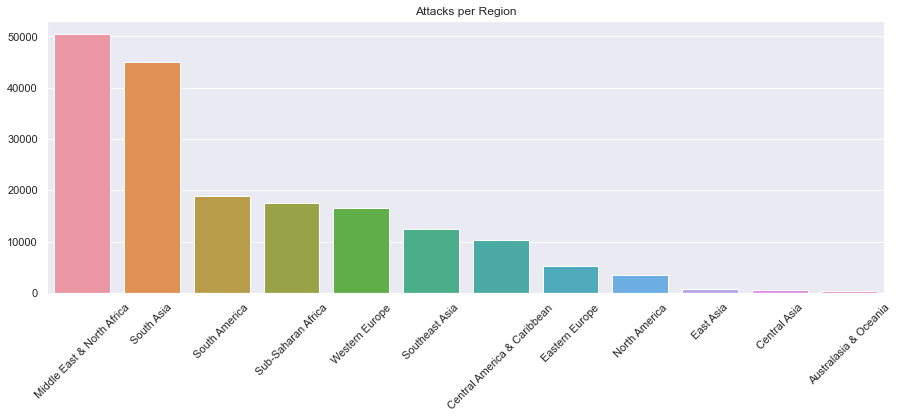

```python
sns.set(font_scale=1)
country_plt=sns.barplot(df['Region'].value_counts()[:13].index,df['Region'].value_counts()[:15].values,figure=plt.figure(figsize=(15,5)))
plt.title('Attacks per Region')
country_plt.set_xticklabels(country_plt.get_xticklabels(), rotation=45)
```

ANALYSIS:  
These are the regions under maximum attack and would require more protection.

1. Middle East
2. South Asia

**ATTACK TYPE AND ATTACK**

```python
df_at =df.groupby('AttackType').agg({'AttackType': [("Attack","count")]})
df_at=pd.DataFrame(df_at)
df_at
```

| AttackType | AttackType Attack |
| --- | --- |
| Armed Assault | 42669 |
| Assassination | 19312 |
| Bombing/Explosion | 88255 |
| Facility/Infrastructure Attack | 10356 |
| Hijacking | 659 |
| Hostage Taking (Barricade Incident) | 991 |
| Hostage Taking (Kidnapping) | 11158 |
| Unarmed Assault | 1015 |
| Unknown | 7276 |

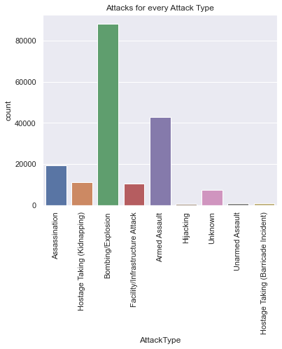

```python
at_plt=sns.countplot(x=df["AttackType"],figure=plt.figure(figsize=(6,5)))
at_plt.set_xticklabels(at_plt.get_xticklabels(), rotation=90)
plt.title('Attacks for every Attack Type')
sns.set(font_scale=1)
```

ANALYSIS:  
Most attacks took place in the form of bombing/explosion and armed assault in order to threaten the people.

**TARGET AND ATTACK**

**TARGET LOCATION**

```python
df_region =df.groupby('Target').agg({'Target': [("Attack","count")]})
df_region=pd.DataFrame(df_region)
df_region
```

| Target | Target Attack |
| --- | --- |
| "A. Xhuvani" University | 1 |
| "Administration Post" | 1 |
| "Building Society" | 1 |
| "Businessmen" Express, Cairo to Luxor | 1 |
| "Colombia" crude oil pipeline | 1 |
| ... | ... |
| yugoslav travel agency | 1 |
| yugoslavia embassy | 1 |
| yugoslavian embassy | 1 |
| zone1(bus station,policestation,private home,red cross)(8thave &3rdstreet) | 1 |
| Électricité de France (EDF) in Furiani | 1 |

86006 rows × 1 columns

```
C:\Users\Leechita G\anaconda3\lib\site-packages\seaborn\_decorators.py:36: FutureWarning: Pass the following variables as keyword args: x, y. From version 0.12, the only valid positional argument will be `data`, and passing other arguments without an explicit keyword will result in an error or misin…
  warnings.warn(
```

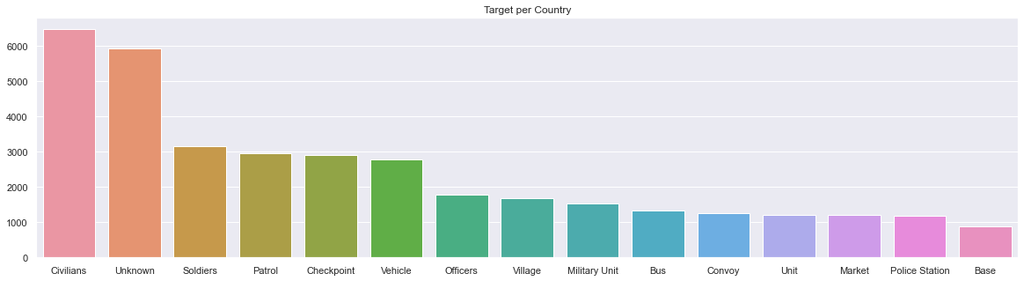

```python
sns.barplot(df['Target'].value_counts()[:15].index,df['Target'].value_counts()[:15].values,figure=plt.figure(figsize=(20,5)))
plt.title('Target per Country')
```

ANALYSIS:  
The above mentioned categories are the targets that are highly prone to danger.

**TARGET TYPE**

```python
df_t =df.groupby('Target_type').agg({'Target_type': [("Attack","count")]})
df_t=pd.DataFrame(df_t)
df_t
```

| Target_type | Target_type Attack |
| --- | --- |
| Abortion Related | 263 |
| Airports & Aircraft | 1343 |
| Business | 20669 |
| Educational Institution | 4322 |
| Food or Water Supply | 317 |
| Government (Diplomatic) | 3573 |
| Government (General) | 21283 |
| Journalists & Media | 2948 |
| Maritime | 351 |
| Military | 27984 |
| NGO | 970 |
| Other | 137 |
| Police | 24506 |
| Private Citizens & Property | 43511 |
| Religious Figures/Institutions | 4440 |
| Telecommunication | 1009 |
| Terrorists/Non-State Militia | 3039 |
| Tourists | 440 |
| Transportation | 6799 |
| Unknown | 5898 |
| Utilities | 6023 |
| Violent Political Party | 1866 |

```
C:\Users\Leechita G\anaconda3\lib\site-packages\seaborn\_decorators.py:36: FutureWarning: Pass the following variables as keyword args: x, y. From version 0.12, the only valid positional argument will be `data`, and passing other arguments without an explicit keyword will result in an error or misin…
  warnings.warn(
```

[output not shown]

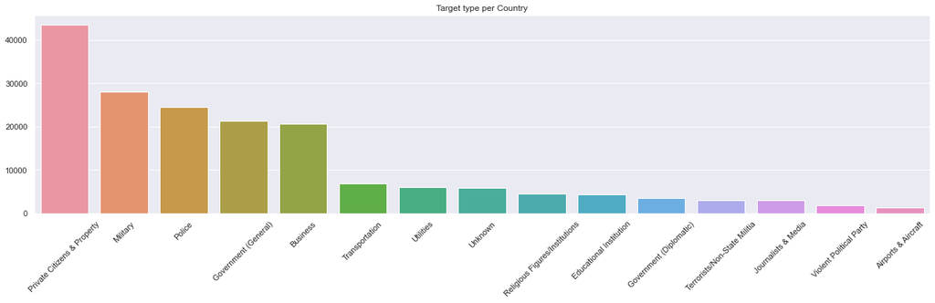

```python
sns.barplot(df['Target_type'].value_counts()[:15].index,df['Target_type'].value_counts()[:15].values,figure=plt.figure(figsize=(22,5)))
plt.title('Target type per Country')
plt.xticks(rotation=45)
```

**Specifically the above mentioned places must be under high protection to avoid unexpected attacks and loss of life.**

**PEOPLE KILLED IN EACH CITY,REGION AND MONTH**

```python
df_2= df.groupby(['City', 'Region', 'Month'])['Killed'].sum()
df_2=df_2.sort_values(ascending=False)
df_2
```

```
City           Region                      Month
New York City  North America               9        2771.0
Baghdad        Middle East & North Africa  7        2307.0
                                           10       1956.0
                                           12       1881.0
                                           2        1776.0
                                                     ...
Kipolot        Southeast Asia              8           0.0
Kira           Sub-Saharan Africa          11          0.0
Kiran          South Asia                  1           0.0
                                           3           0.0
zinarag        Southeast Asia              10          0.0
Name: Killed, Length: 69963, dtype: float64
```

```python
x=df_2.head(15)
x=pd.DataFrame(x)
x
```

| City | Region | Month | Killed |
| --- | --- | --- | --- |
| New York City | North America | 9 | 2771.0 |
| Baghdad | Middle East & North Africa | 7 | 2307.0 |
|  |  | 10 | 1956.0 |
|  |  | 12 | 1881.0 |
|  |  | 2 | 1776.0 |
|  |  | 4 | 1713.0 |
|  |  | 8 | 1709.0 |
|  |  | 9 | 1705.0 |
|  |  | 3 | 1687.0 |
| Tikrit | Middle East & North Africa | 6 | 1675.0 |
| Baghdad | Middle East & North Africa | 11 | 1626.0 |
|  |  | 5 | 1612.0 |
|  |  | 1 | 1591.0 |
|  |  | 6 | 1588.0 |
| Gikoro | Sub-Saharan Africa | 4 | 1180.0 |

**ANALYSIS:**

1. 2771 people are dead in September in New York City of the North American region.
2. Middle East and North Africa region is also highly prone to attacks leading to loss of life especially in Baghdad and Tikrit in all months of the year.
3. Highest number of deaths are in September and July.

**GROUP, REGION, MONTH AND KILLED**

```python
df_2= df.groupby(['Group', 'Region', 'Month'])['Killed'].sum()
df_2=df_2.sort_values(ascending=False)
df_2.head(15)
```

```
Group                                        Region                      Month
Islamic State of Iraq and the Levant (ISIL)  Middle East & North Africa  6        6327.0
Unknown                                      Middle East & North Africa  7        5350.0
                                                                         8        5046.0
                                                                         12       4572.0
                                                                         2        4548.0
                                                                         3        4485.0
                                                                         11       4451.0
                                                                         6        4431.0
                                                                         5        4387.0
                                                                         10       4385.0
                                                                         1        4308.0
Islamic State of Iraq and the Levant (ISIL)  Middle East & North Africa  8        4255.0
Unknown                                      Middle East & North Africa  4        3959.0
                                                                         9        3769.0
Islamic State of Iraq and the Levant (ISIL)  Middle East & North Africa  10       3470.0
Name: Killed, dtype: float64
```